# EOLIA Trial Supplementary Analyses

## Overview

This supplement provides additional analyses for the primary analysis in `EOLIA_BART_RD_RR.html`. All preprocessing mirrors the primary analysis exactly so that results are directly comparable.

All treatment effects are reported on the **risk difference (RD) scale**: CATE(x) = P(Y=1 | Z=1, X=x) − P(Y=1 | Z=0, X=x), where Y=1 denotes death at day 60 and Z=1 denotes assignment to ECMO. A negative CATE indicates ECMO reduces mortality.

**Analyses included:**

- Prior sensitivity across all four BART hyperparameters (k, power, base, ntree).
- Comparator methods: Bayesian Causal Forest, Causal Forest, and XGBoost T-learner and S-learner.
- Treatment effect heterogeneity by baseline risk:
  - Within-stratum risk differences across quartiles of predicted baseline mortality
  - BART-estimated CATEs conditioned on the prognostic score as a single covariate

# Setup

```r
library(BART)
library(dbarts)
library(caret)
library(dplyr)
library(ggplot2)
library(tidyr)
library(purrr)
library(rpart)
library(rpart.plot)
library(gtsummary)
library(bcf)
library(xgboost)

source("clusterfunctions.R")

# Global seed
GLOBAL_SEED <- 60622
set.seed(GLOBAL_SEED)
```

## Data Preprocessing

```r
# Load the dataset
load("../../data/EOLIA_04122017/eolia_form.RData")

# Clean up variable types and remove rows with missing data
dat <- eolia[, c("age", "sexe", "ards_etiology_regroup3",
                 "pao2_fio2_rando", "paco2_rando",
                 "vasopressors_rando", "prone_rando", "manoeuvre_rando",
                 "steroid_rando", "sepsis_class_bin", "immunocomp_adm",
                 "lactate_rando", "rrt_rando", "sofa_rando_bin", "del_intub_rando_bin",
                 "compliance_rando", "driving_rando",
                 "ecmo_centers.f",
                 "bras_en", "statut_vital_j60")]

addmargins(table(dat$bras_en, dat$statut_vital_j60))
```

```
##
##             0   1 Sum
##   ECMO     80  44 124
##   Control  68  57 125
##   Sum     148 101 249
```

```r
cat("Number of missing observations for each variables:\n")
```

```
## Number of missing observations for each variables:
```

```r
sapply(dat, function(x) sum(is.na(x)))
```

```
##                    age                   sexe ards_etiology_regroup3
##                      0                      0                      0
##        pao2_fio2_rando            paco2_rando     vasopressors_rando
##                      1                      1                      0
##            prone_rando        manoeuvre_rando          steroid_rando
##                      0                      0                      0
##       sepsis_class_bin         immunocomp_adm          lactate_rando
##                      0                      1                     13
##              rrt_rando         sofa_rando_bin    del_intub_rando_bin
##                      0                      0                      0
##       compliance_rando          driving_rando         ecmo_centers.f
##                     58                     58                      0
##                bras_en       statut_vital_j60
##                      0                      0
```

```r
dat$compliance_rando <- dat$driving_rando <- NULL
dat <- dat[complete.cases(dat), ] # rows without missing values
dat$pao2_fio2_rando <- round(dat$pao2_fio2_rando)

cat("Number of observations in the analysis database: ", nrow(dat), "\n")
```

```
## Number of observations in the analysis database:  235
```

```r
addmargins(table(dat$bras_en, dat$statut_vital_j60))
```

```
##
##             0   1 Sum
##   ECMO     73  43 116
##   Control  64  55 119
##   Sum     137  98 235
```

```r
# Impute NA values in a character column "adlmorelessf" with the mode
impute_mode <- function(column) {
  mode_value <- names(which.max(table(column, useNA = "no")))
  column[is.na(column)] <- mode_value
  return(column)
}

# Replace NA values with the median of each numerical column
impute_with_median <- function(x) {
  apply(x, 2, function(col) {
    col[is.na(col)] <- median(col, na.rm = TRUE)
    return(col)
  })
}

# Standardize continuous covariates
contvar_unscaled <- dat[, c("age", "pao2_fio2_rando", "paco2_rando", "lactate_rando")]
dat$age <- (dat$age - mean(dat$age)) / sd(dat$age)
dat$pao2_fio2_rando <- (dat$pao2_fio2_rando - mean(dat$pao2_fio2_rando)) / sd(dat$pao2_fio2_rando)
dat$paco2_rando <- (dat$paco2_rando - mean(dat$paco2_rando)) / sd(dat$paco2_rando)
dat$lactate_rando <- (dat$lactate_rando - mean(dat$lactate_rando)) / sd(dat$lactate_rando)

# Treatment variable as logical
dat$bras_en <- ifelse(dat$bras_en == "ECMO", TRUE, FALSE)

# Rename covariates for easier use in decision tree plotting
colnames(dat) <- c("Age", "Sexe", "ARDS etiology", "PaO2/FiO2", "PaCO2",
                        "Vasopressors", "Prone position", "Recruitment maneuvers",
                        "Corticosteroids", "Severe sepsis or septic shock",
                        "Immunocompromised", "Lactate", "Renal replacement therapy",
                        "SOFA score", "Interval between start on MV and randomization",
                        "Center",
                        "z", "dead60")

# Check the updated data structure
head(dat)
```

```
##          Age Sexe       ARDS etiology  PaO2/FiO2       PaCO2 Vasopressors
## 1 -0.5977715  Man Bacterial pneumonia -0.3230895 -0.57005009           No
## 2 -1.1846176  Man               Other -1.2694351  0.07961902          Yes
## 3  1.5295458  Man               Other  0.8052456  1.24902342          Yes
## 4  0.4292093  Man Bacterial pneumonia -0.5414769 -0.11528171          Yes
## 5 -0.8911945  Man               Other -0.1047021  0.46942049           No
## 7  0.2824977  Man               Other  0.9508372  0.33948667          Yes
##   Prone position Recruitment maneuvers Corticosteroids
## 1             No                    No              No
## 2             No                    No              No
## 3            Yes                    No              No
## 4             No                    No              No
## 5             No                   Yes              No
## 7             No                    No              No
##   Severe sepsis or septic shock Immunocompromised    Lactate
```

[output cut: 20 more lines]

```r
# Set up variables for the model
z <- dat[, "z"]  # Binary treatment variable
y <- dat[, "dead60"]  # Outcome variable
X <- dat[, !(names(dat) %in% c("z", "dead60"))]  # Covariates

# Reconstruct unscaled version of X for descriptive purposes
X_unscaled <- X
X_unscaled$Age <- contvar_unscaled$age
X_unscaled$`PaO2/FiO2` <- contvar_unscaled$pao2_fio2_rando
X_unscaled$PaCO2 <- contvar_unscaled$paco2_rando
X_unscaled$Lactate <- contvar_unscaled$lactate_rando
```

# Sensitivity analysis of the prior specification

To assess whether the limited-HTE finding is robust to prior specification, we refit BART under a panel of prior configurations spanning under-regularized, default, CV-selected, and over-regularized regimes. The four hyperparameters varied are:

- **k** (leaf-value shrinkage): primarily controls effect size magnitude. Larger k shrinks fitted values more tightly toward the overall mean.
- **power** (depth penalty): primarily controls interaction capacity. Higher power penalizes deeper trees, making treatment-by-covariate interactions harder to learn.
- **base** (split probability): also controls interaction capacity. Lower base reduces the probability of splitting, discouraging the deep trees needed for interaction detection.
- **ntree** (ensemble size): more trees reduce each tree’s individual contribution.

```r
# If the saved CV output is available, load the actual CV-selected
# hyperparameters rather than hardcoding them.

# best_hp <- which.min(orig_cv$CVMSE)
# cv_power <- orig_cv$Power[best_hp]
# cv_base  <- orig_cv$Base[best_hp]
# cv_ntree <- orig_cv$Ntrees[best_hp]

# If the saved CV output is not available, use the values reported in
# the primary analysis output. VERIFY these match before submitting.
cv_power <- 3
cv_base  <- 0.25
cv_ntree <- 400

prior_grid <- tibble::tribble(
  ~label,             ~power, ~base, ~k, ~ntree,
  "default",               2, 0.95, 2, 200,     # BART default
  "original_cv_selected", cv_power, cv_base, 2, cv_ntree, # CV-selected in primary analysis
  "under_regularized",     1, 0.95, 1, 50,      # everything relaxed: deep trees, few, weak k
  "deep_trees_default_k",  1, 0.95, 2, 200,     # isolates tree-depth effect (power=1 vs 2)
  "low_k_default_struct",  2, 0.95, 1, 200,     # isolates leaf-shrinkage effect (k=1 vs 2)
  "high_k_default_struct", 2, 0.95, 5, 200,     # strong leaf shrinkage
  "mildly_over_reg",       2, 0.75, 3, 200,
  "over_regularized",      3, 0.50, 3, 400
)

print(prior_grid)
```

```
## # A tibble: 8 × 5
##   label                 power  base     k ntree
##   <chr>                 <dbl> <dbl> <dbl> <dbl>
## 1 default                   2  0.95     2   200
## 2 original_cv_selected      3  0.25     2   400
## 3 under_regularized         1  0.95     1    50
## 4 deep_trees_default_k      1  0.95     2   200
## 5 low_k_default_struct      2  0.95     1   200
## 6 high_k_default_struct     2  0.95     5   200
## 7 mildly_over_reg           2  0.75     3   200
## 8 over_regularized          3  0.5      3   400
```

### Helper: fit BART once with fixed priors, return full posterior

```r
fit_bart_fixed <- function(X, y, z, power, base, k, ntree,
                           seed = GLOBAL_SEED, nchains = 4,
                           ndpost = 1000, nskip = 500, keepevery = 1) {

  x  <- cbind(z, X)
  x1 <- x; x1$z <- TRUE
  x0 <- x; x0$z <- FALSE

  set.seed(seed)
  bartmod1 <- lbart.cluster(
    x.train = x, y.train = y, x.test = x1,
    power = power, base = base, k = k, ntree = ntree,
    nchains = nchains, ndpost = ndpost, nskip = nskip, keepevery = keepevery
  )

  set.seed(seed + 1)
  bartmod0 <- lbart.cluster(
    x.train = x, y.train = y, x.test = x0,
    power = power, base = base, k = k, ntree = ntree,
    nchains = nchains, ndpost = ndpost, nskip = nskip, keepevery = keepevery
  )

  # Collapse chains: (ndraws * nchains) x n
  yhat1 <- apply(bartmod1$yhat.test, 2, rbind)
  yhat0 <- apply(bartmod0$yhat.test, 2, rbind)

  # Transform latent logit draws to probability draws
  p1 <- plogis(yhat1)  # P(Y=1 | Z=1, X)
  p0 <- plogis(yhat0)  # P(Y=1 | Z=0, X)

  # CATE on RD scale
  cate_post <- p1 - p0

  # Per-patient posterior summaries
  cate_mean <- colMeans(cate_post)
  cate_sd   <- apply(cate_post, 2, sd)
  cate_lo   <- apply(cate_post, 2, quantile, 0.025)
  cate_hi   <- apply(cate_post, 2, quantile, 0.975)

list(
    cate_mean = cate_mean,
    cate_sd   = cate_sd,
    cate_lo   = cate_lo,
    cate_hi   = cate_hi,
    cate_post = cate_post,
    p1        = p1,
    p0        = p0,
    config    = list(power = power, base = base, k = k, ntree = ntree)
  )
}
```

## Run the prior-sensitivity grid

```r
prior_results <- vector("list", nrow(prior_grid))
names(prior_results) <- prior_grid$label

for (i in seq_len(nrow(prior_grid))) {
  cfg <- prior_grid[i, ]
  cat("\n--- Fitting", cfg$label, "---\n")
  cat("  power =", cfg$power, "  base =", cfg$base,
      "  k =", cfg$k, "  ntree =", cfg$ntree, "\n")

  prior_results[[i]] <- fit_bart_fixed(
    X = X, y = y, z = z,
    power = cfg$power, base = cfg$base, k = cfg$k, ntree = cfg$ntree
  )
}
```

```
##
## --- Fitting default ---
##   power = 2   base = 0.95   k = 2   ntree = 200
## [1]  744 4148 3964   18
## [1] 5901 1155 3962 6046
##
## --- Fitting original_cv_selected ---
##   power = 3   base = 0.25   k = 2   ntree = 400
## [1]  744 4148 3964   18
## [1] 5901 1155 3962 6046
##
## --- Fitting under_regularized ---
##   power = 1   base = 0.95   k = 1   ntree = 50
## [1]  744 4148 3964   18
## [1] 5901 1155 3962 6046
##
## --- Fitting deep_trees_default_k ---
##   power = 1   base = 0.95   k = 2   ntree = 200
## [1]  744 4148 3964   18
## [1] 5901 1155 3962 6046
##
## --- Fitting low_k_default_struct ---
##   power = 2   base = 0.95   k = 1   ntree = 200
## [1]  744 4148 3964   18
## [1] 5901 1155 3962 6046
##
## --- Fitting high_k_default_struct ---
##   power = 2   base = 0.95   k = 5   ntree = 200
## [1]  744 4148 3964   18
## [1] 5901 1155 3962 6046
##
## --- Fitting mildly_over_reg ---
##   power = 2   base = 0.75   k = 3   ntree = 200
## [1]  744 4148 3964   18
## [1] 5901 1155 3962 6046
##
## --- Fitting over_regularized ---
##   power = 3   base = 0.5   k = 3   ntree = 400
## [1]  744 4148 3964   18
## [1] 5901 1155 3962 6046
```

```r
saveRDS(prior_results, "prior_results.rds")
```

## Summary table across prior settings

```r
prior_summary <- purrr::map_dfr(seq_along(prior_results), function(i) {
  r <- prior_results[[i]]
  tibble::tibble(
    label = names(prior_results)[i],
    power = r$config$power,
    base = r$config$base,
    k = r$config$k,
    ntree = r$config$ntree,
    mean_CATE = mean(r$cate_mean),
    median_CATE = median(r$cate_mean),
    sd_across_pts = sd(r$cate_mean),
    avg_within_post_sd = mean(r$cate_sd),
    shrinkage_ratio = sd(r$cate_mean) / mean(r$cate_sd),
  )
})

knitr::kable(prior_summary, digits = 3,
             caption = "CATE summaries across hyperparameter configurations")
```

CATE summaries across hyperparameter configurations

| label | power | base | k | ntree | mean_CATE | median_CATE | sd_across_pts | avg_within_post_sd | shrinkage_ratio |
| --- | --- | --- | --- | --- | --- | --- | --- | --- | --- |
| default | 2 | 0.95 | 2 | 200 | -0.079 | -0.084 | 0.017 | 0.190 | 0.089 |
| original_cv_selected | 3 | 0.25 | 2 | 400 | -0.046 | -0.047 | 0.007 | 0.151 | 0.046 |
| under_regularized | 1 | 0.95 | 1 | 50 | -0.090 | -0.086 | 0.038 | 0.263 | 0.146 |
| deep_trees_default_k | 1 | 0.95 | 2 | 200 | -0.077 | -0.080 | 0.017 | 0.204 | 0.084 |
| low_k_default_struct | 2 | 0.95 | 1 | 200 | -0.104 | -0.110 | 0.031 | 0.232 | 0.135 |
| high_k_default_struct | 2 | 0.95 | 5 | 200 | -0.034 | -0.035 | 0.005 | 0.137 | 0.034 |
| mildly_over_reg | 2 | 0.75 | 3 | 200 | -0.051 | -0.053 | 0.007 | 0.160 | 0.045 |
| over_regularized | 3 | 0.50 | 3 | 400 | -0.042 | -0.044 | 0.005 | 0.146 | 0.036 |

The shrinkage ratio is defined as the SD of posterior-mean CATEs across patients divided by the average within-patient posterior SD. Values near 0 indicate the posterior cannot separate patients (heavy shrinkage); values above 1 indicate clear between-patient separation relative to posterior uncertainty.

## CATE distributions across prior settings

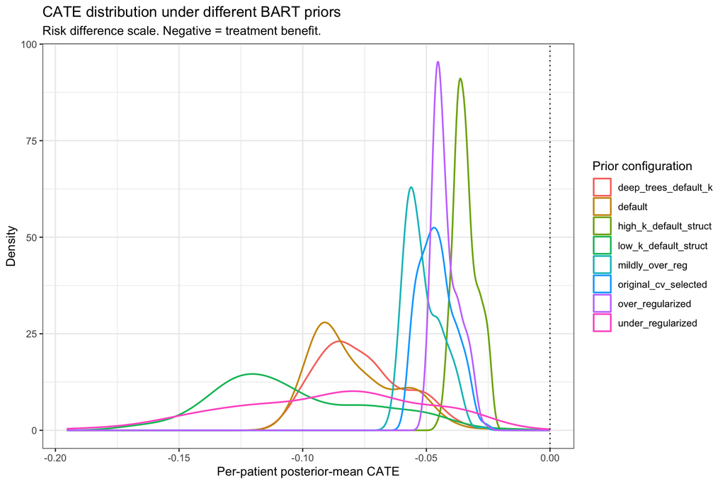

```r
plot_df <- purrr::map_dfr(seq_along(prior_results), function(i) {
  tibble::tibble(
    label = names(prior_results)[i],
    cate  = prior_results[[i]]$cate_mean
  )
})

ggplot(plot_df, aes(x = cate, color = label)) +
  geom_density(linewidth = 0.7) +
  geom_vline(xintercept = 0, linetype = "dotted") +
  labs(
    title = "CATE distribution under different BART priors",
    subtitle = "Risk difference scale. Negative = treatment benefit.",
    x = "Per-patient posterior-mean CATE",
    y = "Density",
    color = "Prior configuration"
  ) +
  theme_bw()
```

```r
ggsave("fig_prior_sensitivity_density.png", width = 9, height = 6, dpi = 300)
```

## Caterpillar plots with individual credible intervals

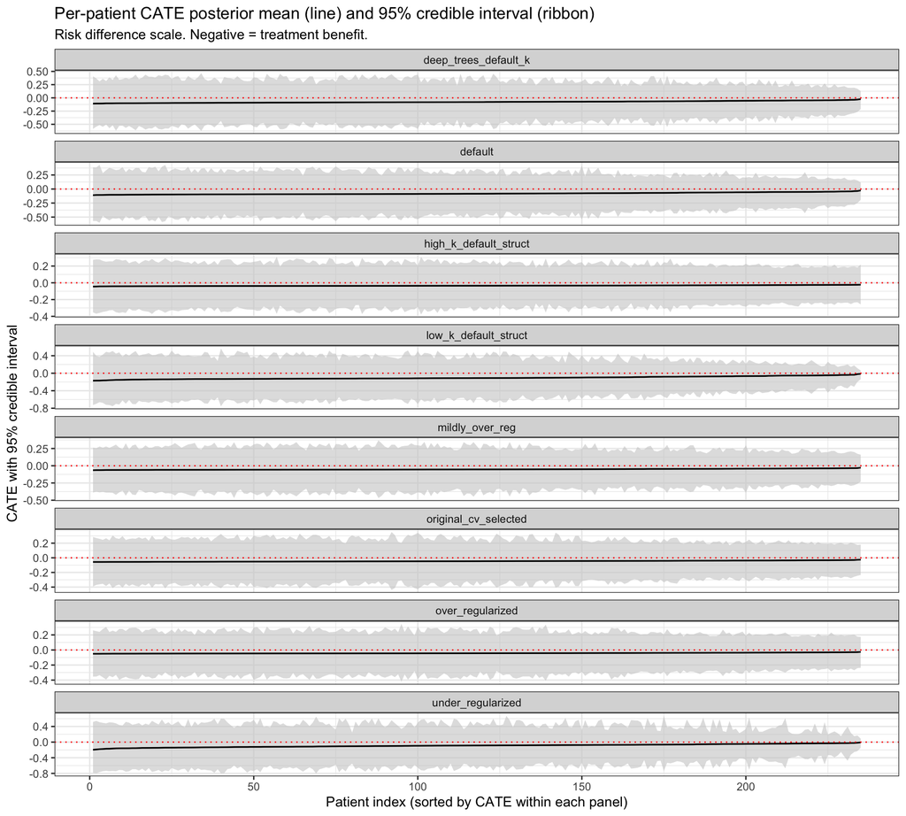

```r
key_labels <- prior_grid$label

cat_df <- purrr::map_dfr(key_labels, function(lab) {
  r <- prior_results[[lab]]
  tibble::tibble(
    label = lab,
    cate  = r$cate_mean,
    lo    = r$cate_lo,
    hi    = r$cate_hi
  ) %>%
    arrange(cate) %>%
    mutate(rank = row_number())
})

ggplot(cat_df, aes(x = rank, y = cate)) +
  geom_ribbon(aes(ymin = lo, ymax = hi), fill = "grey80", alpha = 0.6) +
  geom_line(linewidth = 0.6) +
  geom_hline(yintercept = 0, linetype = "dotted", color = "red") +
  facet_wrap(~ label, ncol = 1, scales = "free_y") +
  labs(
    title = "Per-patient CATE posterior mean (line) and 95% credible interval (ribbon)",
    subtitle = "Risk difference scale. Negative = treatment benefit.",
    x = "Patient index (sorted by CATE within each panel)",
    y = "CATE with 95% credible interval"
  ) +
  theme_bw()
```

```r
ggsave("fig_caterpillar_priors.png", width = 10, height = 9, dpi = 300)
```

# Bayesian Causal Forest

Bayesian Causal Forest (Hahn, Murray, and Carvalho 2020) separates the prognostic surface from the treatment-effect surface using distinct tree ensembles.

```r
# BCF requires a numeric covariate matrix: expand factors
X_mat <- model.matrix(~ . - 1, data = X)

# BCF requires a propensity score estimate (even in an RCT, we estimate it to capture minor imbalances)
pihat_glm <- fitted(glm(as.numeric(z) ~ ., data = as.data.frame(X_mat),
                        family = binomial))

set.seed(GLOBAL_SEED)
sink(tempfile())
bcf_fit <- bcf::bcf(
  y = y, z = as.numeric(z),
  x_control = X_mat, x_moderate = X_mat, pihat = pihat_glm,
  nburn = 2000, nsim = 2000, n_chains = 4,
  random_seed = GLOBAL_SEED, no_output = TRUE
)
sink()

mu_post  <- bcf_fit$mu    # (nsim * n_chains) x n, latent scale
tau_post <- bcf_fit$tau   # (nsim * n_chains) x n, latent scale

# Latent-to-risk-difference conversion. Under a probit link:
# P(Y=1 | Z, X) = Phi(mu + tau * Z)
# So CATE_RD = Phi(mu + tau) - Phi(mu)
cate_bcf_post <- pnorm(mu_post + tau_post) - pnorm(mu_post)

cate_bcf_mean <- colMeans(cate_bcf_post)
cate_bcf_sd   <- apply(cate_bcf_post, 2, sd)
cate_bcf_lo   <- apply(cate_bcf_post, 2, quantile, 0.025)
cate_bcf_hi   <- apply(cate_bcf_post, 2, quantile, 0.975)

cat("BCF (RD scale) summary:\n")
```

```
## BCF (RD scale) summary:
```

```r
cat("mean of posterior-mean CATEs:", round(mean(cate_bcf_mean), 4), "\n")
```

```
## mean of posterior-mean CATEs: -0.0209
```

```r
cat("SD across patients:", round(sd(cate_bcf_mean), 5), "\n")
```

```
## SD across patients: 0.00358
```

```r
cat("mean within-patient post SD:", round(mean(cate_bcf_sd), 5), "\n")
```

```
## mean within-patient post SD: 0.03155
```

```r
cat("shrinkage ratio:", round(sd(cate_bcf_mean) / mean(cate_bcf_sd), 3), "\n")
```

```
## shrinkage ratio: 0.113
```